# KEY 05 basic stats

## 3.3 Problem 3 - Galapagos Finch data

- The following problems will all work with the `galapago-finch.csv` data
- See the Data heading above to ensure that the data is loaded in your quarto document
- We will only be working with the data from 2012
- Be sure to run the following code:

```r
finch_2012 <- finch |>
  filter(year == 2012)
```

- Use `finch_2012` to answer the following problems

3.1 Make a “global” density plot of the `bdepth` variable.

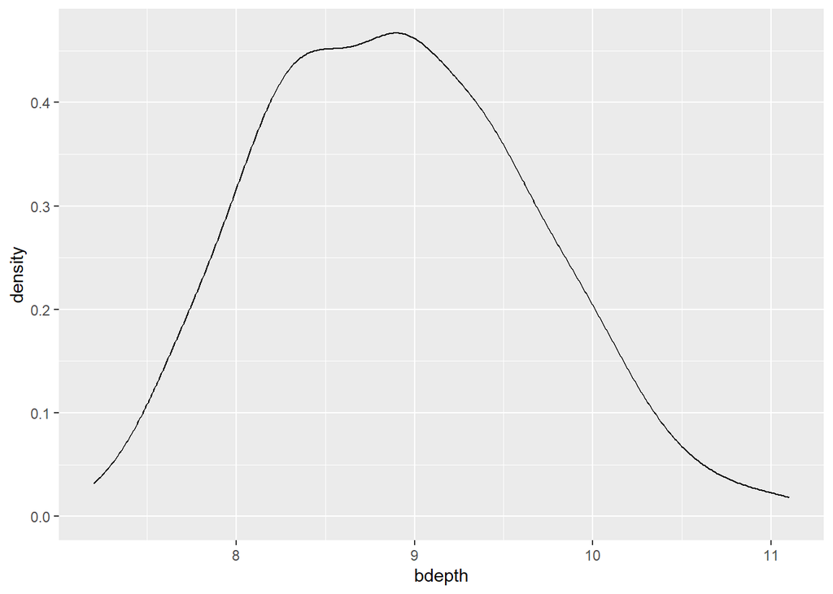

```r
ggplot(finch_2012,
       aes(x = bdepth)) +
  geom_density()
```

3.2 Assess the normality of the `bdepth` variable based on the density plot made in 3.1

```r
# the bdepth data appears to be normal
# There is a peak in the middle, and the density declines fairly symmetrically in both directions
# Ther is a small "lump" on the left side near the peak, and possibly a very small right skew
```

3.3 Make a “global” histogram plot of the `bdepth` variable.

- set `bins = 15` inside your `geom_histogram()` argument

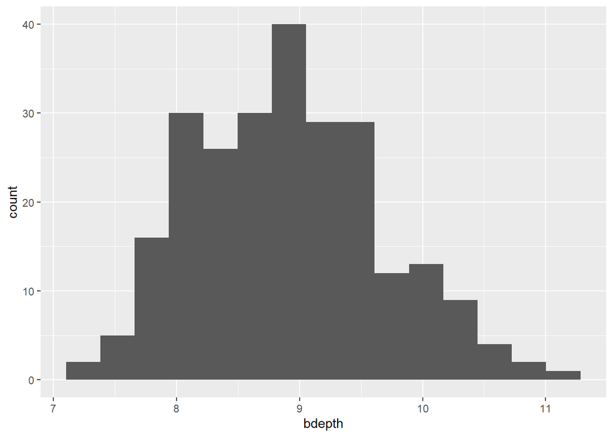

```r
ggplot(finch_2012,
       aes(x = bdepth)) +
  geom_histogram(bins = 15)
```

3.4 Assess the normality of the `bdepth` variable based on the histogram plot made in 3.2

```r
# the bdepth data appears to be normal
# There is a peak in the middle, and the density declines fairly symmetrically in both directions
# Ther is a small "lump" on the left side near the peak, and possibly a very small right skew
```

3.5 Use `shapiro.test()` to formally test whether or not this variable is normally distributed. Display the results of this test.

```r
shapiro.test(finch_2012$bdepth)
```

```
    Shapiro-Wilk normality test

data:  finch_2012$bdepth
W = 0.98874, p-value = 0.05011
```

### 3.3.1 GRADED

3.6 Interpret the results of the Shapiro test performed in 3.6.

```r
### GRADED
# The result of the test has a p-value of 0.05011 which is greater than the alpha value of 0.05.
# This does technically pass the normality test, although just barely.
```

3.7 Make a boxplot of the `bdepth` variable, but this time have the data grouped by species. I.e., you should have two box plots and the fill of each should correspond to the species.

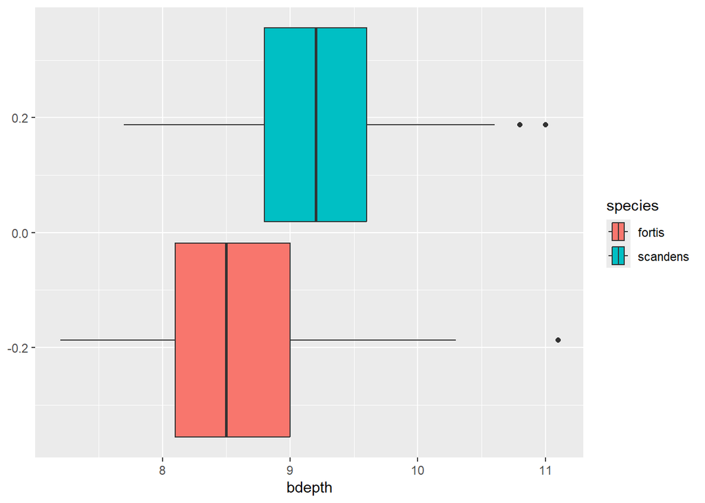

```r
ggplot(finch_2012,
       aes(x = bdepth,
           fill = species)) +
  geom_boxplot()
```

3.8 Interpret the box plots you made in 3.7. Be sure to interpret the box plot for each species separately, and tell me specifically what you are looking at.

```r
# Both box plots for fortis and scandens look normal
# The black median line is almost perfectly in the middle of each box
# The length of the tails for scandens looks almost perfectly symmetrical
# the taile for fortis look close, although the right tail looks a little longer
# Scandens has two dots to the right side
# Fortis only has one dot, but it is further away than the two dots in scandens
```

3.9 Calculate the mean, SD, N, SE, and approximate 95% CIs for both species and display the output as a tibble or data frame in your document.

```r
finch_2012_ci <- finch_2012 |>
  group_by(species) |>
  summarize(m_bd = mean(bdepth),
            sd_bd = sd(bdepth),
            n_bd = n()) |>
  mutate(se_bd = sd_bd / sqrt(n_bd),
         l95 = m_bd - 2 * se_bd,
         u95 = m_bd + 2 * se_bd)
finch_2012_ci
```

```
# A tibble: 2 × 7
  species   m_bd sd_bd  n_bd  se_bd   l95   u95
  <fct>    <dbl> <dbl> <int>  <dbl> <dbl> <dbl>
1 fortis    8.61 0.733   121 0.0666  8.47  8.74
2 scandens  9.19 0.669   127 0.0594  9.07  9.30
```

### 3.3.2 GRADED

3.10 Make a plot showing the point and range of the 95% CIs for both species

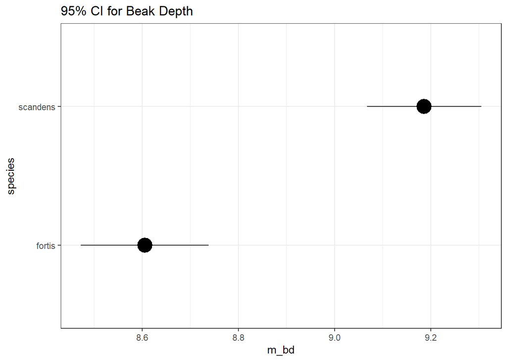

```r
### GRADED
ggplot(finch_2012_ci,
       aes(y = species,
             x = m_bd,
             xmin = m_bd - 2 * se_bd,
             xmax = m_bd + 2 * se_bd)) +
  geom_pointrange(size = 1.5) +
  theme_bw()+
  labs(title = "95% CI for Beak Depth")
```

3.11 Compare the 95% CIs for beak depth in the two species and interpret the results. Be sure to state if the population means are the same or different.

```r
# The two CIs do not over lap
# 8.5 to 8.7 vs. 9.1 to 9.3
# Therefore, we can conclude, at the 95% confidence level, that the mean beak depth for these two species are different.
```